# Italy Coronavirus Outbreak: numbers and stats

Andrea Cirillo

2020-02-24

## Italy NCOV-19 outbreak

For personal reasons I am trying to track the number of NCOV-19 confirmed cases in Italy as well as the number of deaths (since I live in Italy, it is not difficult to guess the personal reason…). I am thus regularly monitoring news from the italian official sources like “Regione Lombardia” and “Protezione Civile”.

You can find on a [Google Sheet](https://docs.google.com/spreadsheets/d/1mnhZe6_5m1wtLqDaTU-JzXrAHd0OKV7Uhrkh6G2BFn0/edit?usp=sharing) the raw data I am collecting.

### number of confirmed cases and deaths in Italy

Here is an attempt to visualize historical series of total confirmed cases and deaths

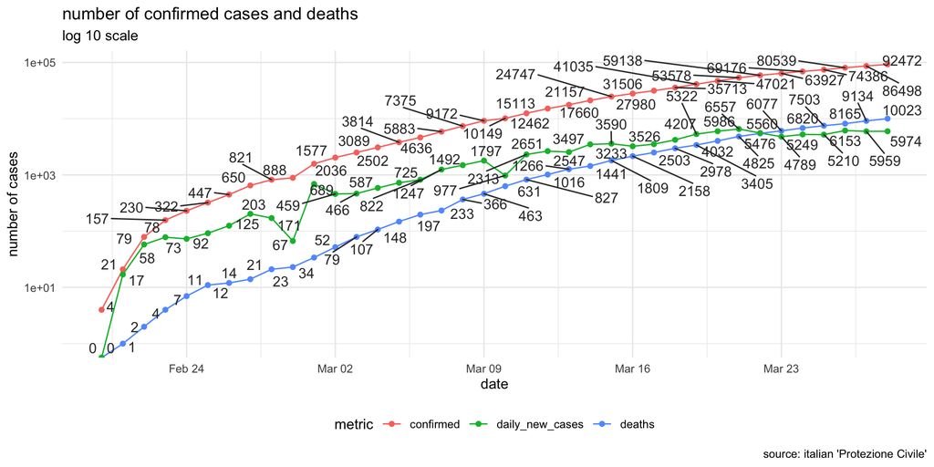

### daily change in confirmed cases in Italy

and finally here a visualization of daily change in confirmed cases:

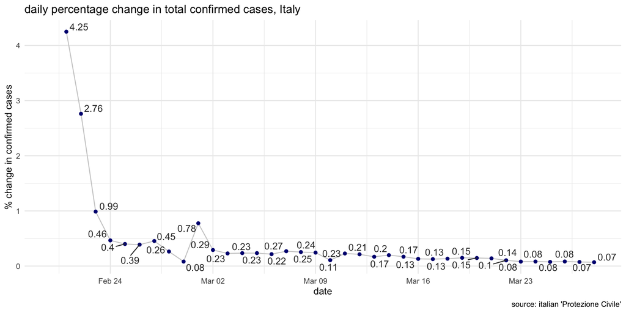

It is interesting to compare this trend with the one observed in Mainland China

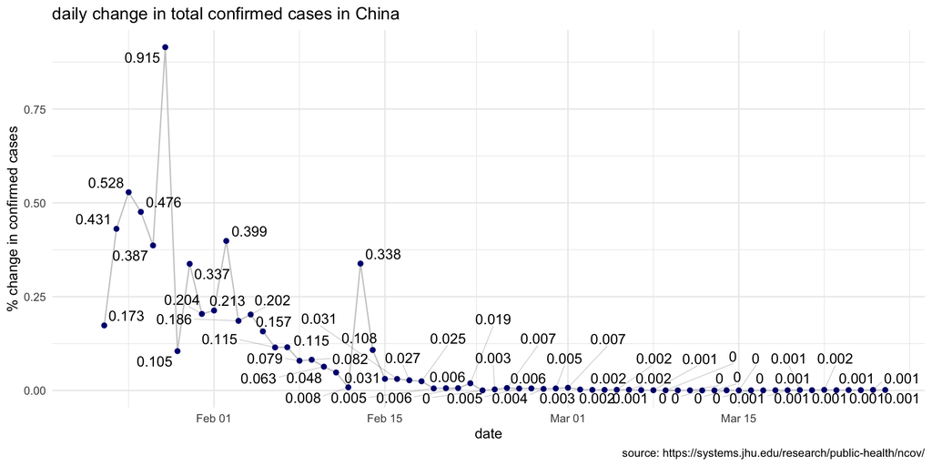

### daily confirmed cases in Italy

The most waited day from the beginning of the outbreak is the one in which the number of daily confirmed new cases will reach its peak and we will start to see a reduction of new cases within the subsequent days. Let’s thus monitor this metric as well in the following plot:

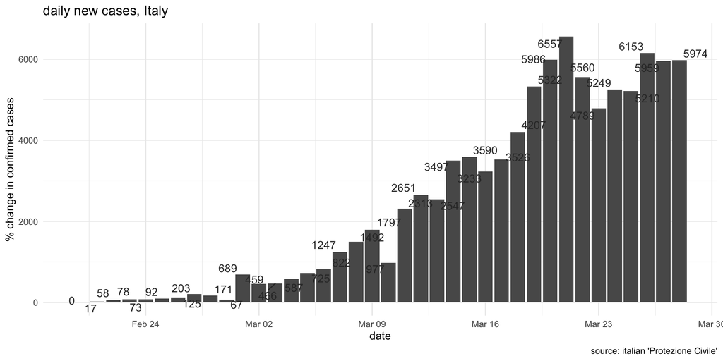

```r
italy_data %>%
  ggplot(aes(x = date,y = daily_new_cases, label = daily_new_cases))+
geom_bar(stat= 'identity')+
      ggrepel::geom_text_repel(colour = "gray20")+
  theme_minimal()+
  theme(legend.position = "bottom")+
  labs(title= "daily new cases, Italy",
       x = "date", y = "% change in confirmed cases", caption = "source: italian 'Protezione Civile'")
```

### daily change in confirmed cases in Lombardy

As you probably already know the most serious coronavirus outbreak started directly in Lombardy, where I currently live and I am writing from. I am therefore taking separared note of number related this region. You can find them on the [Google Sheet](https://docs.google.com/spreadsheets/d/1mnhZe6_5m1wtLqDaTU-JzXrAHd0OKV7Uhrkh6G2BFn0/edit?usp=sharing) and the daily change plotted below:

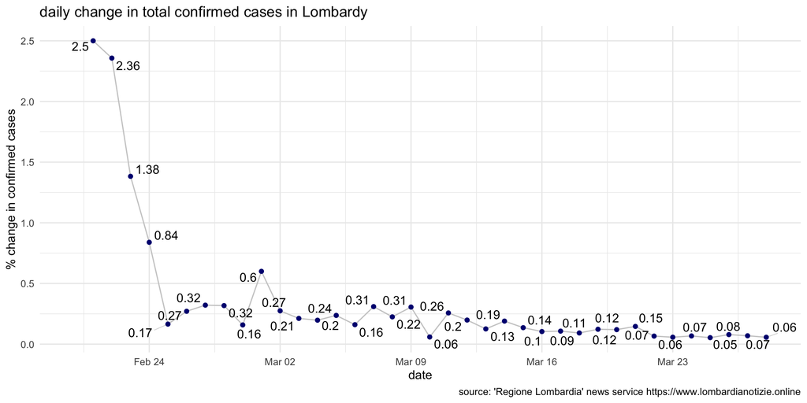

### comparison between Lombardy and Hubei province

Since Lombardy is the first place where coronavirus really appeared in Italy, and it currently is the region where the main outbreak is observed, I thought it would have been interesting to compare the shape of the cumulated number of confirmed cases measured in Lombardy with the same number measured in Hubei from the beginning of the outbreak.

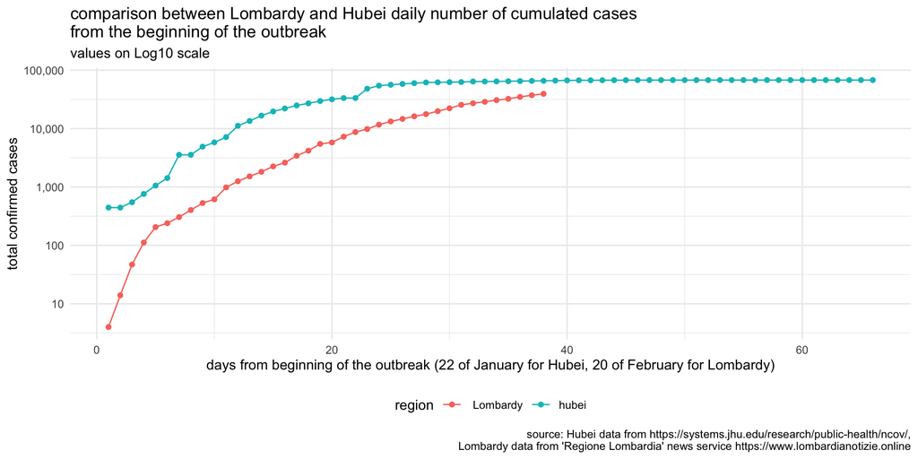

Unfortunately, Lombardy pattern looks quite different from day 5 on, with a steeper increase compared to the chinese one. This is also the reason that guided the adoption from the Italian Government of a nearly complete lock-down of the Country.

### daily new cases

As done for Italy as a whole, let’s monitor the number of daily new cases for Lombardy as well:

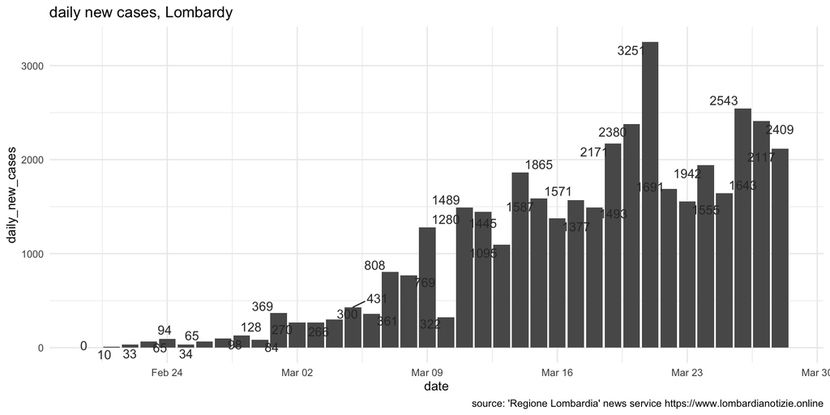

```r
Lombardy_data %>%
  ggplot(aes(x = date,y = daily_new_cases, label = daily_new_cases))+
geom_bar(stat= 'identity')+
      ggrepel::geom_text_repel(colour = "gray20")+
  theme_minimal()+
  theme(legend.position = "bottom")+
  labs(title= "daily new cases, Lombardy",
          x = "date",caption = "source: 'Regione Lombardia' news service https://www.lombardianotizie.online")
```